# Streaming platform

Amedeo Gagliardi

19/5/2022

I have put together the content database of Netflix, Disney Plus, Amazon Prime and Hulu. The whole dataset contains data for 22996 and have the following information for each movies: *Title*, *Type*, *Director*, *Cast*, *Country*, *Date of insertion the platform catalogue*, *Date of release*, *Rating*. *Duration* and *Genres*.

I have created two separate tables to manage more in detail the countries of production and the genre of the movie/TV show. Regarding the genres, since the single streaming platform use similar but slightly different names to indicate the genres I have modified their name a little to harmonize them, as example: *Action & adventure* on Neflix and *Action-Adventure* on Disney+ became *Action and Adventure*.

**Netflix** launched its streaming platform in 2008 as well as **Hulu**. **Amazon prime video** debuted in 2006 in United States, with the former name of **Amazon Unbox** and change its designationto the current name in 2018. Among these big four, **Disney Plus** is the most recent, being launched in 2019.

The following plot shows the total content of each platform (*updated to 6 months ago*)

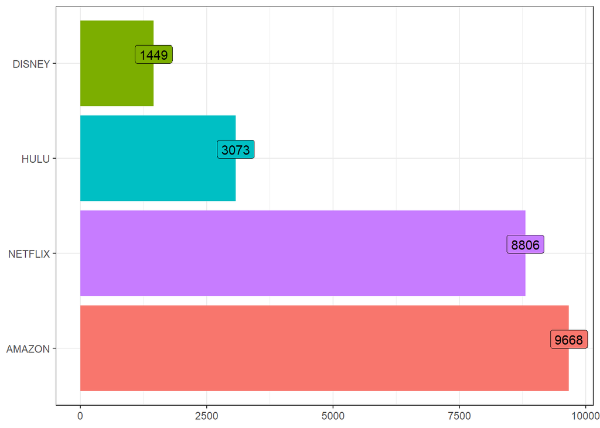

As we can see **Amazon** have the greatest amount of content followed by **Netflix**. **Disney Plus** trails at the end of the ladder, but we must take account of its relative young age compared to the other streming platform.

We can breakdown each platform content into the two main categories, *Movies* and *TV Shows*.

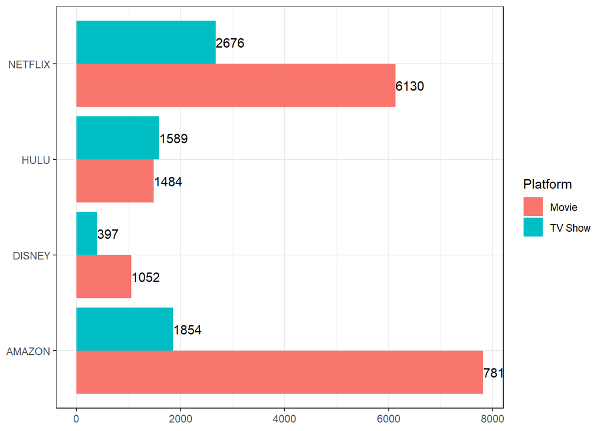

The only platform with more TV Shows than movies is **Hulu**. Catalogue of **Netflix** (69.61%) and **Amazon** (80.82%) is formed vastly by movies.